# Social and economic networks

Handout 8

Juan José Martín y Christian Strasser

**The files *GA_edges.txt* and *GA_nodes.txt* contain the links and nodes (with several attributes) of the sexual contact network among “Grey’s Anatomy” characters (seasons 1-8) collected by A. Leavitt (https://github.com/alexleavitt/SNAinRworkshop).**

**(Caution!) There’s scarcely anything new under the sun. In particular, in Leavitt’s github for his workshop on Social Network Analysis cited above you can find scripts with an analysis of this network with ERGM, you can get inspiration from them, but nothing else than inspiration. For instance: he provides the instructions for solving our points (d) and (e), you can use them but the conclusions must be your harvest; he uses here and there functions from the Dephi package, you cannot unless you explain carefully what you are doing with them (they are not necessary, here); he uses some cunning parameters for instance to upload his dataframes (which are not our dataframes, but have similar features) of to add colors to the nodes, if you use them you must explain what they do.**

**Define a network with these data frames, and make sure that its nodes have as attributes at least their names, sex, birthyear, race and position.**

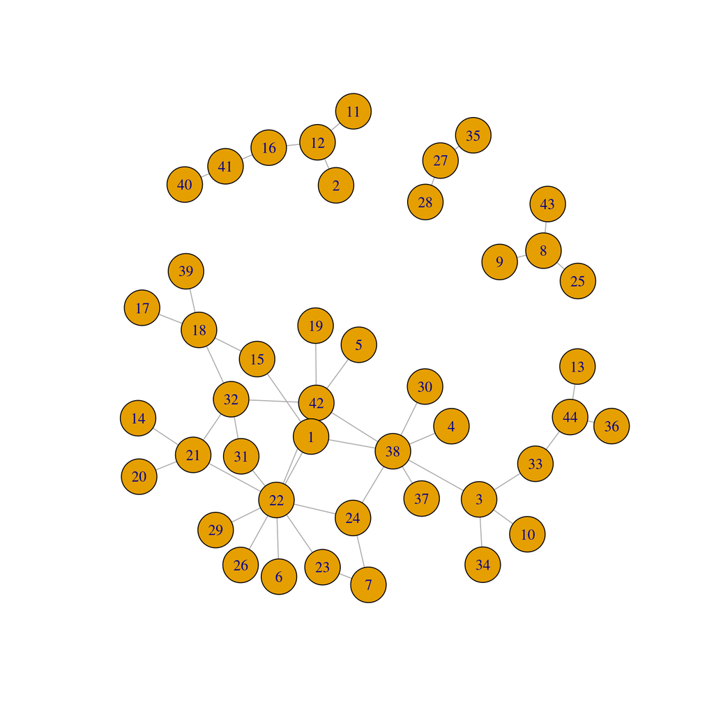

```r
df_e = read.csv("datasets/GA_edges.txt", sep = "\t")
df_v = read.csv("datasets/GA_nodes.txt", sep = "\t")
g = graph_from_data_frame(df_e, directed = FALSE)

plot(g)
```

Añadimos los atributos a los nodos:

```r
for(i in vertex_attr(g)$name){
  g = set_vertex_attr(g, name = "sex", index = i, value = as.character(df_v[i,2]))
  g = set_vertex_attr(g, name = "race", index = i, value = as.character(df_v[i,3]))
  g = set_vertex_attr(g, name = "birthyear", index = i, value = as.character(df_v[i,4]))
  g = set_vertex_attr(g, name = "position", index = i, value = as.character(df_v[i,5]))
  g = set_vertex_attr(g, name = "season", index = i, value = as.numeric(df_v[i,6]))
  g = set_vertex_attr(g, name = "sign", index = i, value = as.character(df_v[i,7]))
  g = set_vertex_attr(g, name = "name", index = i, value = as.character(df_v[i,1]))
}
```

A continuación, vemos todos los atributos añadidos a cada nodo.

```r
vertex_attr(g)
```

```
## $name
##  [1] "derek"        "karev"        "sloan"        "chief"
##  [5] "burton"       "owen"         "perkins"      "torres"
##  [9] "kepner"       "lexi"         "ben"          "lloyd"
## [13] "tucker"       "ellis_grey"   "yang"         "izzie"
## [17] "grey"         "thatch_grey"  "o'malley"     "steve"
## [21] "lucy"         "mrs._seabury" "olivia"       "mostow"
## [25] "pierce"       "addison"      "adele"        "altman"
## [29] "amelia"       "arizona"      "ava"          "avery"
## [33] "bailey"       "catherine"    "colin"        "denny"
## [37] "finn"         "hahn"         "hank"         "megan"
## [41] "nancy"        "preston"      "reed"         "susan_grey"
##
## $sex
##  [1] "M" "M" "M" "M" "M" "M" "M" "F" "F" "F" "M" "M" "M" "F" "F" "F" "F"
```

[output cut: 43 more lines]

```r
V(g)$sign[is.na(V(g)$sign)] = "Unknown"
```

**a) Provide a statistical summary of this network (including a suitable statistical description of the nodes’ attributes that you use in points (c) and (d) below) and plot it with the nodes labelled with the characters’ names and colored with their anatomic sex.**

Datos estadísticos del grafo:

- Order: 44.
- Tamaño: 46
- Densidad: 0.0486
- Componentes: El número de componentes conexos es 4 y sus tamaños son 31, 6, 4, 3
- Diámetro: 8
- Distancia media: 3.4948875
- Transitividad: 0
- Atributo *Sex*:

```r
table(factor(V(g)$sex, labels=unique(V(g)$sex)))
```

```
##
##  M  F
## 23 21
```

- Atributo *Race*:

```r
table(factor(V(g)$race, labels=unique(V(g)$race)))
```

```
##
## White Black Other
##     8     4    32
```

- Atributo *Birthyear*:

```r
table(factor(V(g)$birthyear, labels=unique(V(g)$birthyear)))
```

```
##
## 1966 1970 1972 1954 1973 1965 1975 1980 1982 1971 1957 1978 1969 1955 1984
##    1    1    1    1    1    1    1    1    1    2    2    2    3    3    2
## 1952 1985 1986 1967 1949 1981 1976 1950 1944 1979 1963 1959
##    3    2    3    1    1    1    1    3    2    2    1    1
```

- Atributo *Position*:

```r
table(factor(V(g)$position, labels=unique(V(g)$position)))
```

```
##
## Attending  Resident     Chief Non-Staff     Other     Nurse    Intern
##        14         2         3        12         2         2         9
```

- Atributo *Season*:

```r
table(factor(V(g)$season, labels=unique(V(g)$season)))
```

```
##
##  1  2  7  5  6  3  4  8
## 13 10  5  3  2  5  5  1
```

- Atributo *Sign*:

```r
table(factor(V(g)$sign, labels=unique(V(g)$sign)))
```

```
##
##   Capricorn      Cancer     Scorpio         Leo       Virgo       Libra
##           2           2           5           4           4          10
##       Aries    Aquarius Sagittarius      Gemini     Unknown      Pisces
##           3           1           2           3           3           2
##      Taurus
##           3
```

Ahora visualizamos la red de forma que coloreamos los diferentes nodos según su atributo de “sexo” (Azul: Hombre | Rosa: Mujer).

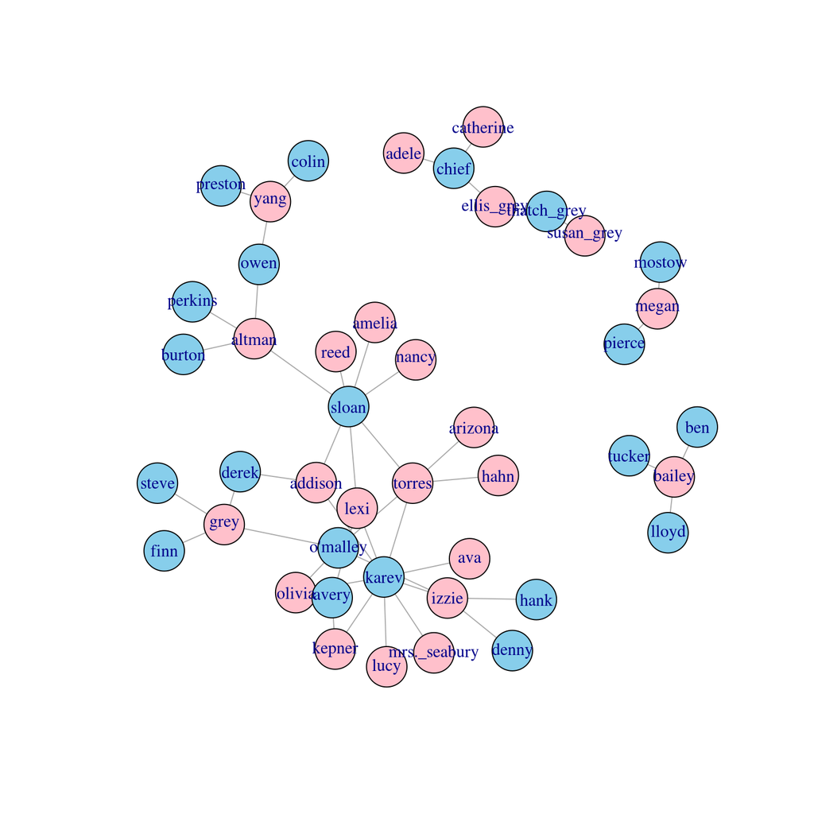

```r
plot(g, vertex.color = c("pink","skyblue")[1+(V(g)$sex=="M")])
```

**b) Is this network bipartite? Justify your answer and explain its meaning for this specific network.**

```r
is_bipartite(g)
```

```
## [1] FALSE
```

No se trata de una red bipartida porque existe al menos un ciclo con un número impar de nodos impidiendo poder hacer una agrupación de los nodos de la red en 2 conjuntos U y V que cumplen con las condiciones para ser una red bipartida. En un ciclo con un número impar de nodos, en esta red, significa que al menos 2 nodos que están relacionados en este ciclo tienen el mismo sexo.

**c) If you wanted to test one single character for sexually transmitted infections, who would he/she be? Why?**

En una red que muestra las relaciones sexuales entre personas, el personaje más importante a analizar sería aquel nodo con mayor grado, que representa el número de personas con las que ha tenido relaciones.

```r
V(g)$name[degree(g)==max(degree(g))]
```

```
## [1] "karev"
```

**d) Fit an ERGM to this network using as predictors its number of edges and of homosexual relations. Explain the results obtained, and check its goodness of fit.**

Primero generamos nuestra red e incluimos los atributos de nombres, sexos, temporadas y año de nacimientos (estos últimos 2 para posteriores ejercicios). Esta clase generada se necesita posteriormente para hacer el modelo de ERGM.

```r
g.net = as.network(as.matrix(as_adjacency_matrix(g)),directed=FALSE)
network::set.vertex.attribute(g.net,"name", V(g)$name)
network::set.vertex.attribute(g.net,"sex", V(g)$sex)
network::set.vertex.attribute(g.net,"season", V(g)$season)
network::set.vertex.attribute(g.net,"birthyear", strtoi(V(g)$birthyear, base = 0L))
g.net
```

```
##  Network attributes:
##   vertices = 44
##   directed = FALSE
##   hyper = FALSE
##   loops = FALSE
##   multiple = FALSE
##   bipartite = FALSE
##   total edges= 46
##     missing edges= 0
##     non-missing edges= 46
##
##  Vertex attribute names:
##     birthyear name season sex vertex.names
##
## No edge attributes
```

Generamos el modelo ERGM según los predictores del número de aristas y el número de aristas entre nodos con el mismo atributo de sexo.

```r
fit_g.net = ergm(g.net ~ edges + nodematch("sex"))
summary(fit_g.net)
```

```
##
## ==========================
## Summary of model fit
## ==========================
##
## Formula:   g.net ~ edges + nodematch("sex")
##
## Iterations:  6 out of 20
##
## Monte Carlo MLE Results:
##               Estimate Std. Error MCMC % p-value
## edges          -2.3003     0.1581      0  <1e-04 ***
## nodematch.sex  -3.1399     0.7260      0  <1e-04 ***
## ---
## Signif. codes:  0 '***' 0.001 '**' 0.01 '*' 0.05 '.' 0.1 ' ' 1
##
##      Null Deviance: 1311.4  on 946  degrees of freedom
##  Residual Deviance:  320.5  on 944  degrees of freedom
##
## AIC: 324.5    BIC: 334.2    (Smaller is better.)
```

El modelo de ERGM analiza los términos que especifican estadísticas de red que son suficientes para representar la distribución de probabilidad en el espacio de las redes de ese tamaño.

En nuestro caso, como representa la salida anterior, los predictores asociados a la cantidad de aristas de nuestra red y la cantidad de aristas entre nodos del mismo sexo, tienen un papel importante (tienen un p-valor < 0.001) para la obtención de las diferentes probabilidades de existir ciertos tipos de enlaces en nuestra red. En este caso, se puede entender que el número total de aristas en esta red ($E$) es igual a la cantidad de aristas entre nodos del mismo sexo ($E_{homo}$) más la cantidad de aristas entre nodos de sexo distinto ($E_{no\_homo}$), $E = E_{homo} + E_{no\_homo}$. Por lo tanto, si mi intención sería generar de forma aletoria la red de este ejercicio, sabiendo la cantidad de aristas que tiene la red y cuantas de estas aristas tienen que cumplir con ser enlaces entre dos nodos del mismo sexo, estas variables tendrían un valor importante para obtener las diferentes probabilidades de existir ciertos tipos de aristas en nuestra red.

A continuación mostramos lo adecuado que es nuestro modelo actual.

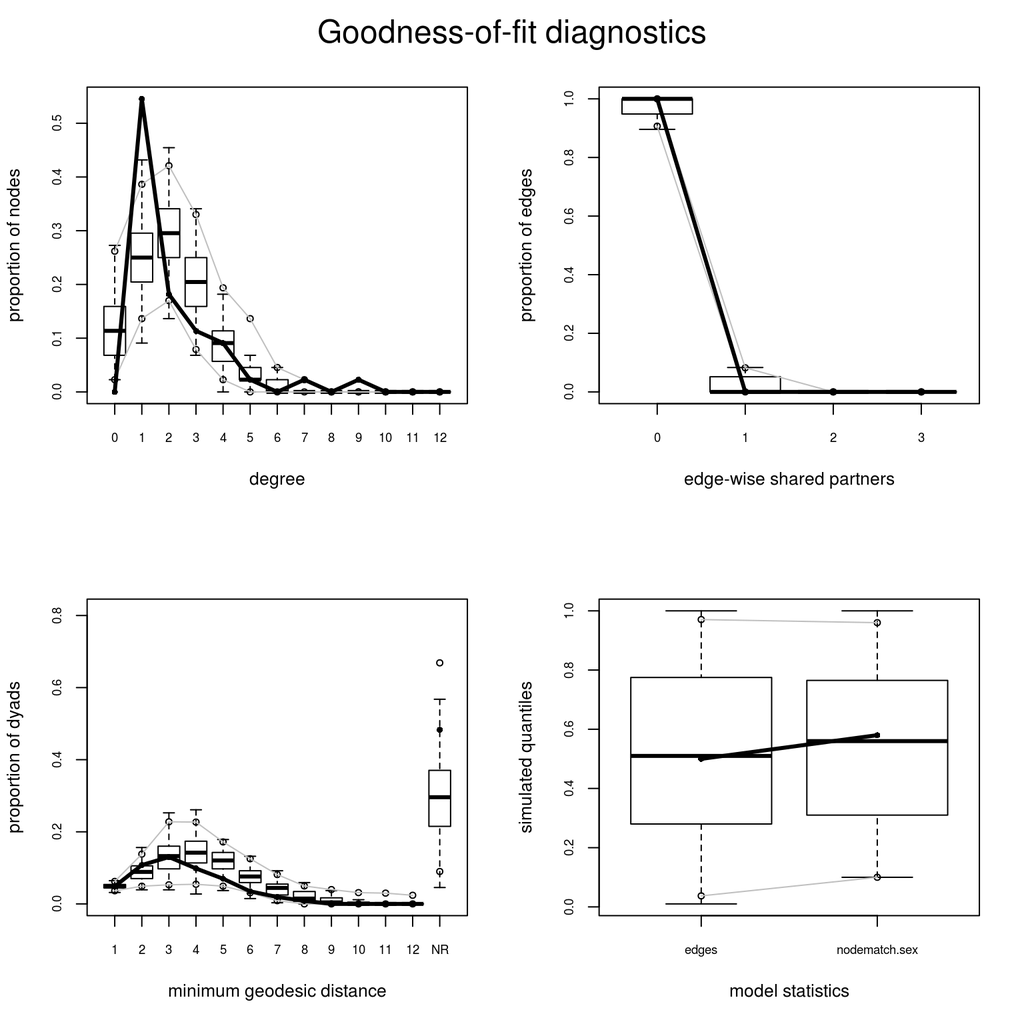

```r
fit.gof_g.net = gof(fit_g.net)
par(mfrow = c(2,2))
plot(fit.gof_g.net)
```

Con estas gráficas podemos ver que no se ajusta del todo a los valores reales, pero aún así, se trata de un primer modelo bastante adecuado.

**e) Add as extra predictors the “monogamy” and difference of age between adjacent nodes (it is done by Leavitt in his workshop). Explain the results obtained, and check its goodness of fit.**

Ampliamos el modelo anterior con la cantidad de aristas que van enlazadas entre nodos de grado 1 (que representa “monogamía” en esta red) y la cantidad de aristas entre nodos con atributo de año de nacimiento diferente.

```r
fit2_g.net = ergm(g.net~edges+nodematch("sex")+degree(1)+absdiff("birthyear"))
summary(fit2_g.net)
```

```
##
## ==========================
## Summary of model fit
## ==========================
##
## Formula:   g.net ~ edges + nodematch("sex") + degree(1) + absdiff("birthyear")
##
## Iterations:  3 out of 20
##
## Monte Carlo MLE Results:
##                   Estimate Std. Error MCMC % p-value
## edges             -0.47057    0.29321      0   0.109
## nodematch.sex     -3.24768    0.71350      0  <1e-04 ***
## degree1            1.98883    0.43700      0  <1e-04 ***
## absdiff.birthyear -0.12410    0.03034      0  <1e-04 ***
## ---
## Signif. codes:  0 '***' 0.001 '**' 0.01 '*' 0.05 '.' 0.1 ' ' 1
##
##      Null Deviance: 1311.4  on 946  degrees of freedom
##  Residual Deviance:  270.3  on 942  degrees of freedom
##
## AIC: 278.3    BIC: 297.8    (Smaller is better.)
```

Como vemos aquí, el predictor de la cantidad de aristas totales en esta red ha perdido importance (su p-valor ha aumentado significativamente) respecto a los otros predictores que sí tienen mayor importancia: la cantidad de enlaces entre nodos del mismo sexo, la cantidad de aristas entre nodos con grado 1 y la cantidad de aristas entre nodos con edades diferentes.

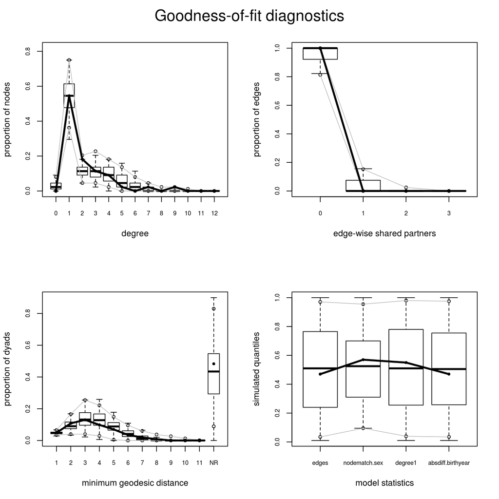

```r
fit2.gof_g.net = gof(fit2_g.net)
par(mfrow = c(2,2))
plot(fit2.gof_g.net)
```

Como vemos, el nuevo modelo se acerca algo más a los valores reales.

**f) Try at least one more model that you consider interesting and that you think could explain better the network (you can add predictors to (e) and remove predictors from it; it is forbidden to use anything related to transitivity, because of (g) below). Justify your choice, explain the results obtained and check whether it fits better the network.**

```r
fit3_g.net = ergm(g.net~edges+nodematch("sex")+degree(1)+absdiff("birthyear")+absdiff("season"))
summary(fit3_g.net)
```

```
##
## ==========================
## Summary of model fit
## ==========================
##
## Formula:   g.net ~ edges + nodematch("sex") + degree(1) + absdiff("birthyear") +
##     absdiff("season")
##
## Iterations:  3 out of 20
##
## Monte Carlo MLE Results:
##                   Estimate Std. Error MCMC % p-value
## edges              0.02889    0.32963      0 0.93017
## nodematch.sex     -3.22119    0.73105      0 < 1e-04 ***
## degree1            1.98519    0.44505      0 < 1e-04 ***
## absdiff.birthyear -0.12333    0.02952      0 < 1e-04 ***
## absdiff.season    -0.25703    0.09248      0 0.00555 **
## ---
## Signif. codes:  0 '***' 0.001 '**' 0.01 '*' 0.05 '.' 0.1 ' ' 1
##
##      Null Deviance: 1311.4  on 946  degrees of freedom
##  Residual Deviance:  261.6  on 941  degrees of freedom
##
## AIC: 271.6    BIC: 295.9    (Smaller is better.)
```

Dado el atributo de ‘temporada’ que corresponde a cuándo ha ocurrido la primera relación sexual de un nodo de esta red, otro modelo interesante sería incluir la cantidad de aristas entre nodos con temporadas diferentes, lo cual quiere decir que aquel nodo que tiene el atributo de temporada menor es el nodo que ya ha tenido otra relación anteriormente.

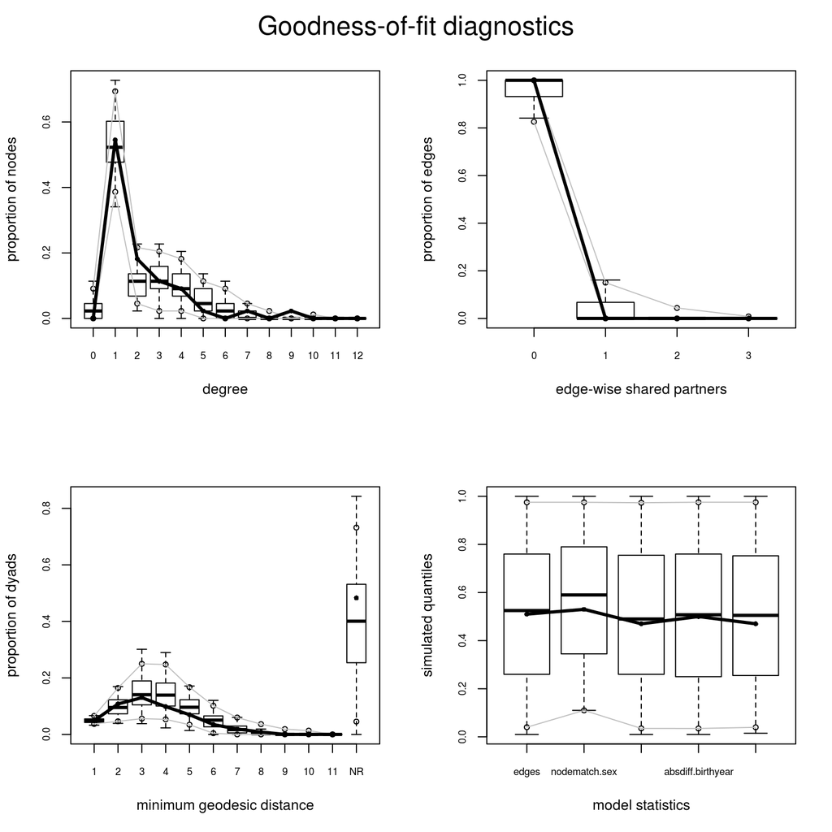

```r
fit3.gof_g.net = gof(fit3_g.net)
par(mfrow=c(2,2))
plot(fit3.gof_g.net)
```

Aunque parece interesante este nuevo modelo, el ajusto no es muy diferente al modelo realizado anteriormente.

**g) What is a triangle in this network? Test the transitivity and the average clustering of this network with the previous models. Explain your results.**

Un triángulo en esta red no dirigida represanta un grupo de tres nodos que forman un clico entre sí, es decir, un grupo de tres presonas donde al menos dos de ellas tienen el mismo sexo y han tenido una relación sexual.

Coeficiente de clustering:

```r
round(transitivity(g, type="average"), 4)
```

```
## [1] 0
```

Coeficiente de transitividad:

```r
round(transitivity(g), 4)
```

```
## [1] 0
```

En esta red no dirigida no existe ningún ciclo entre tres nodos. Aunque sí existen relaciones homosexuales en esta red, estos nodos no forman ningún ciclo con otro nodo, lo cual explica que tanto el coeficiente de clustering, como el coeficiente de transitividad dan 0.

**h) P. S. Bearman, J. Moody and K. Stovel (in their classic “Chains of affection: The structure of adolescent romantic and sexual networks” (*Am. J. Soc.* 110 (2004), 44-91) on romantic relations in a High School which we have mentioned several times in the course) found a prohibition against coupling with a former partner’s former partner’s former partner (and justified it on the basis status implications). Check whether this network satisfies this prohibition, and test it on the previous models.**

Para analizar si nuestra red sigue o no el estudio de “*Chains of affection*” simplemente hay que mirar cuantos ciclos de 4 nodos existen en la red, que corresponde a un caso donde NO se cumple el estudio de “*Chains of affection*”.

```r
cycles = kcycle.census(dat=get.adjacency(g, type=c("both"), attr=NULL, sparse = FALSE), maxlen=4, tabulate.by.vertex=FALSE, mode = "graph")
cycles
```

```
## $cycle.count
## 2 3 4
## 0 0 7
```

Como vemos, ocurren 7 casos donde NO se cumple el estudio de “*Chains of affection*”. Como la instrucción no puede detectar que sean 7 veces las mismas 4 personas, el rango de personas de esta red que no cumplen con el estudio tiene que estar entre 10 personas (las mismas 3 personas en los 7 ciclos, más 7 veces 1 otra personas) y 28 personas (7 veces 4 personas diferentes). Lo cual nos da diferentes fracciones en esta red:

```r
((3 + 1*cycles$cycle.count[3])/(gorder(g)))*100
```

```
##        4
## 22.72727
```

Para 10 personas, un tanto porciento de las personas de la red NO cumplen con el estudio de “*Chains of affection*”.

```r
((4*cycles$cycle.count[3])/(gorder(g)))*100
```

```
##        4
## 63.63636
```

Y para 28 personas, un tanto porciento de las personas de la red NO cumplen con el estudio de “*Chains of affection*”.

En ambos casos, se podría decir que el estudio no se cumple con las personas de esta red.